# Minneapolis College of Art and Design (Minneapolis, MN)

### US student origins

First time degree seeking undergrads

| State | Number of students | Fraction of student body from each state | Fraction of 18 year olds from each state enrolled here |
| --- | --- | --- | --- |
| Alabama | 1 | 1/172 | 1/62938 |
| Alaska | 2 | 1/86 | 1/4259 |
| Arizona | 0 | 0 | 0 |
| Arkansas | 1 | 1/172 | 1/38933 |
| California | 3 | 1/57 | 1/171754 |
| Colorado | 1 | 1/172 | 1/73317 |
| Connecticut | 0 | 0 | 0 |
| Delaware | 0 | 0 | 0 |
| Florida | 3 | 1/57 | 1/80707 |
| Georgia | 0 | 0 | 0 |
| Hawaii | 0 | 0 | 0 |
| Idaho | 0 | 0 | 0 |
| Illinois | 7 | 1/25 | 1/22817 |
| Indiana | 0 | 0 | 0 |
| Iowa | 6 | 1/29 | 1/6976 |
| Kansas | 1 | 1/172 | 1/39133 |
| Kentucky | 0 | 0 | 0 |
| Louisiana | 0 | 0 | 0 |
| Maine | 0 | 0 | 0 |
| Maryland | 1 | 1/172 | 1/78759 |
| Massachusetts | 0 | 0 | 0 |
| Michigan | 2 | 1/86 | 1/66486 |
| Minnesota | 98 | 1/2 | 1/721 |
| Mississippi | 0 | 0 | 0 |
| Missouri | 1 | 1/172 | 1/74065 |
| Montana | 1 | 1/172 | 1/12463 |
| Nebraska | 2 | 1/86 | 1/12847 |
| Nevada | 1 | 1/172 | 1/35313 |
| New Hampshire | 0 | 0 | 0 |
| New Jersey | 0 | 0 | 0 |
| New Mexico | 0 | 0 | 0 |
| New York | 4 | 1/43 | 1/61254 |
| North Carolina | 3 | 1/57 | 1/47190 |
| North Dakota | 1 | 1/172 | 1/9096 |
| Ohio | 0 | 0 | 0 |
| Oklahoma | 0 | 0 | 0 |
| Oregon | 1 | 1/172 | 1/49389 |
| Pennsylvania | 1 | 1/172 | 1/166573 |
| Rhode Island | 0 | 0 | 0 |
| South Carolina | 0 | 0 | 0 |
| South Dakota | 5 | 1/34 | 1/2181 |
| Tennessee | 1 | 1/172 | 1/83746 |
| Texas | 7 | 1/25 | 1/57330 |
| Utah | 0 | 0 | 0 |
| Vermont | 0 | 0 | 0 |
| Virginia | 1 | 1/172 | 1/109389 |
| Washington | 2 | 1/86 | 1/44368 |
| West Virginia | 0 | 0 | 0 |
| Wisconsin | 14 | 1/12 | 1/5369 |
| Wyoming | 1 | 1/172 | 1/6944 |

### Library resources

[output not shown]

## Figures

### Student to faculty ratio compared to similar institutions:

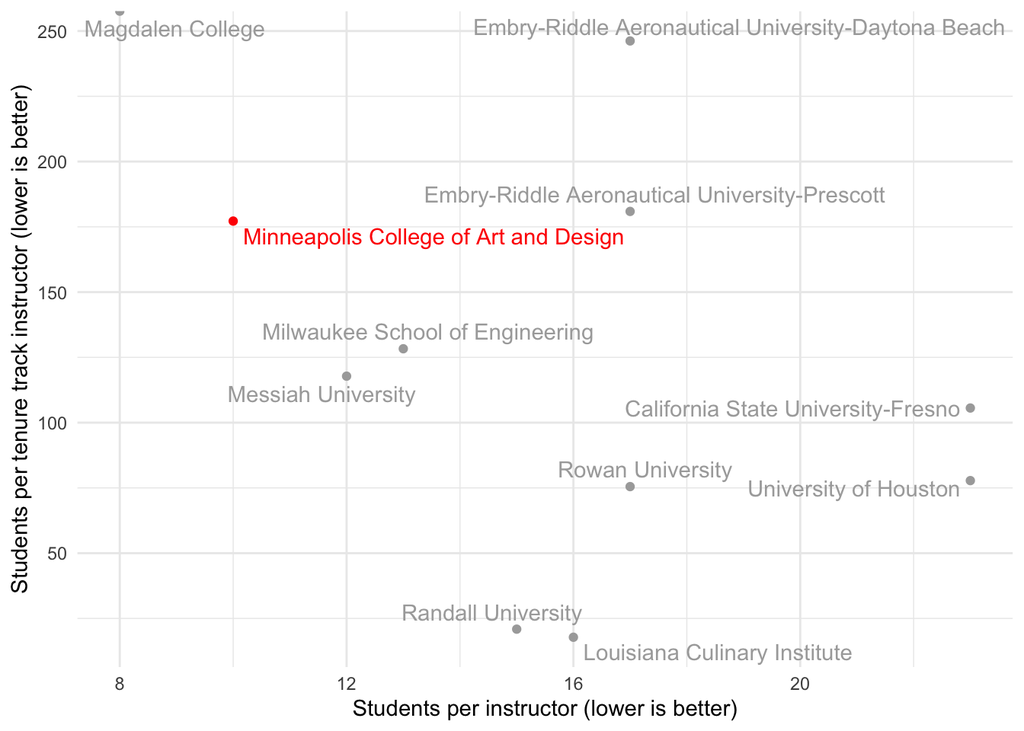

### Students from US

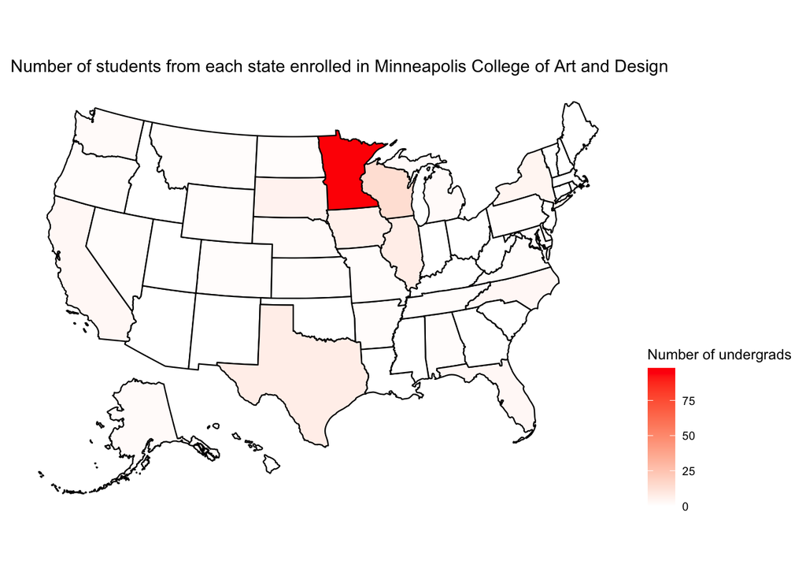

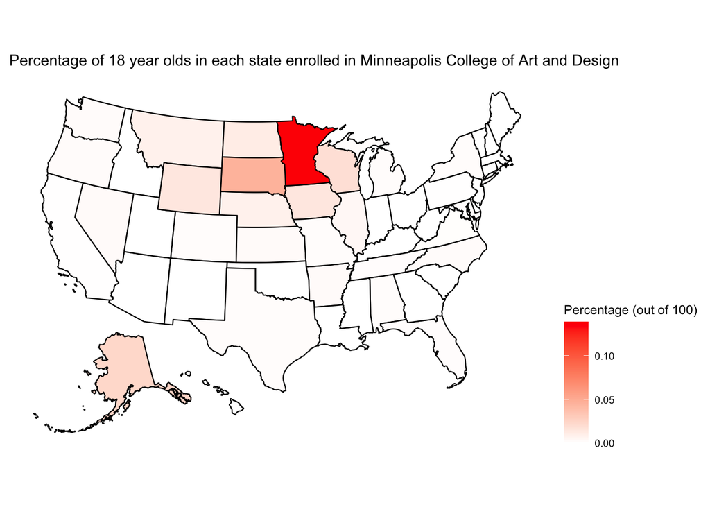